# Chapter 7 - Exercise 9

Zhoumengdi Wang (zxw534)

```r
library(MASS)
library(glmnet)
library(boot)
```

#### (a)

```r
poly_lm = lm(nox ~ poly(dis, 3), data=Boston)
poly_lm.sum = summary(poly_lm)
```

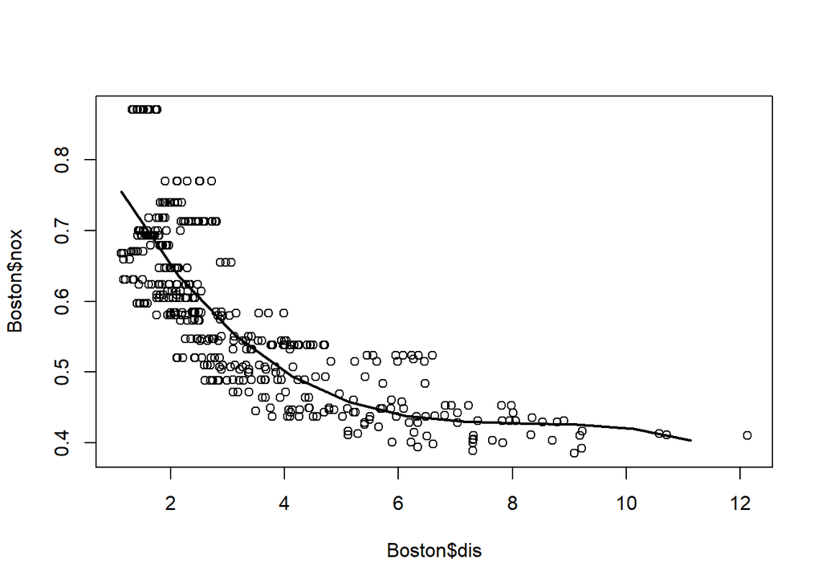

```r
dis_range = range(Boston$dis)
dis_grid=seq(from=dis_range[1], to=dis_range[2])
poly_lm_pred = predict(poly_lm, newdata=list(dis = dis_grid), se=TRUE)

plot(Boston$dis, Boston$nox, xlim=dis_range)
lines(dis_grid, poly_lm_pred$fit, lwd=2)
```

#### (b)

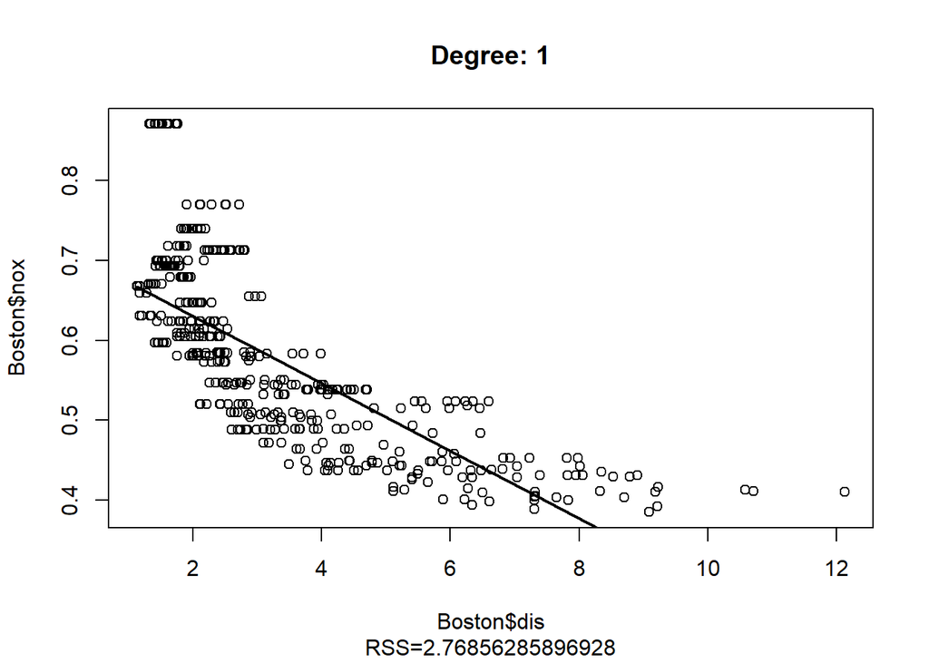

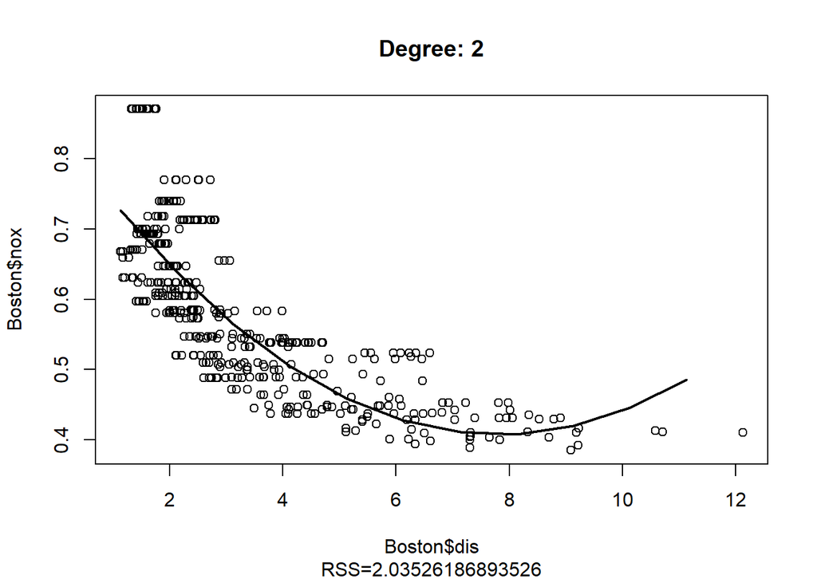

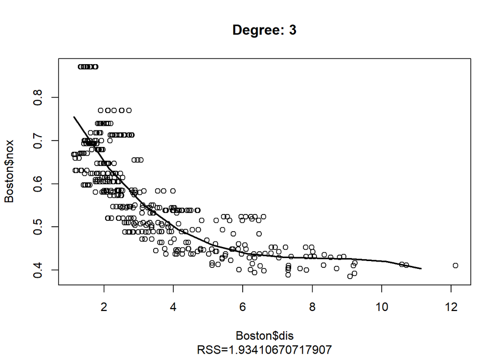

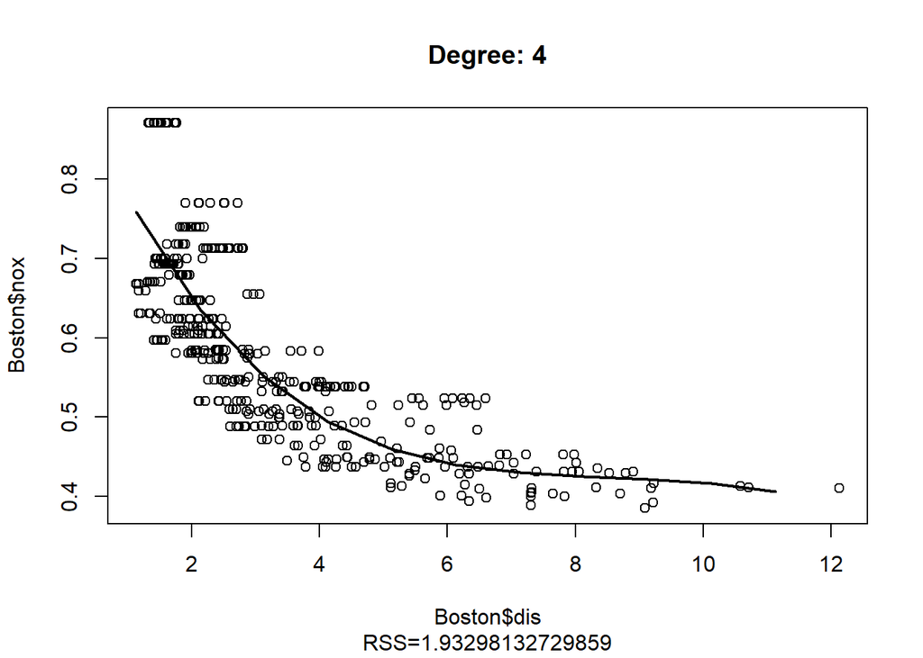

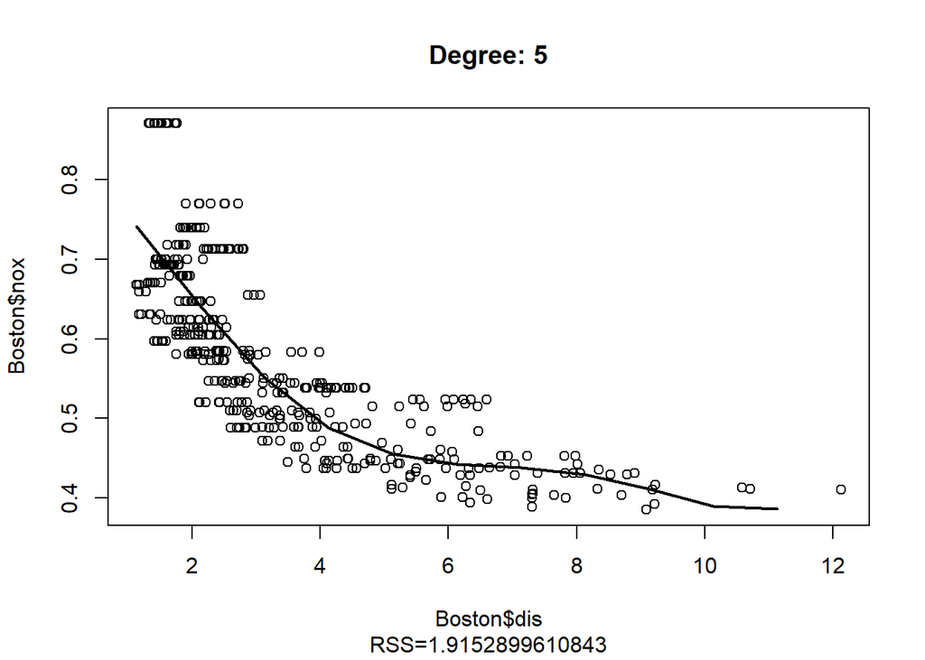

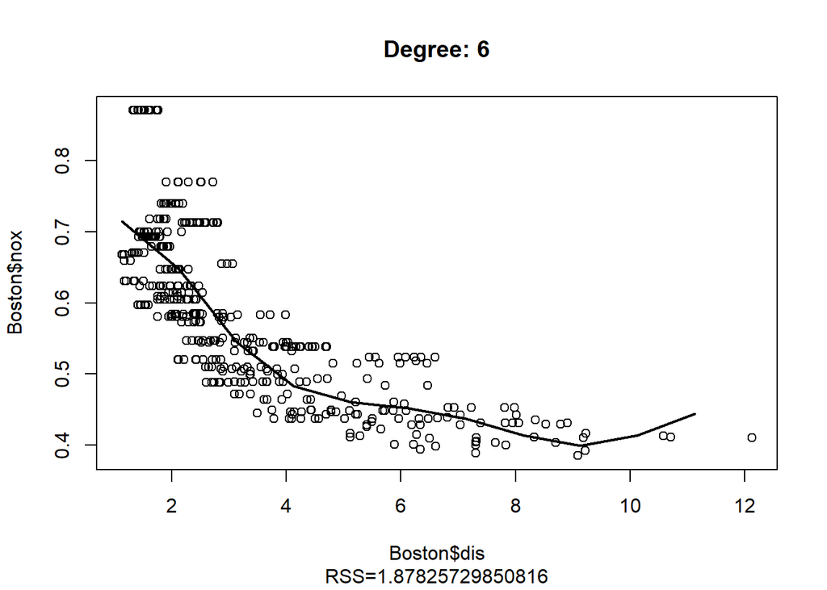

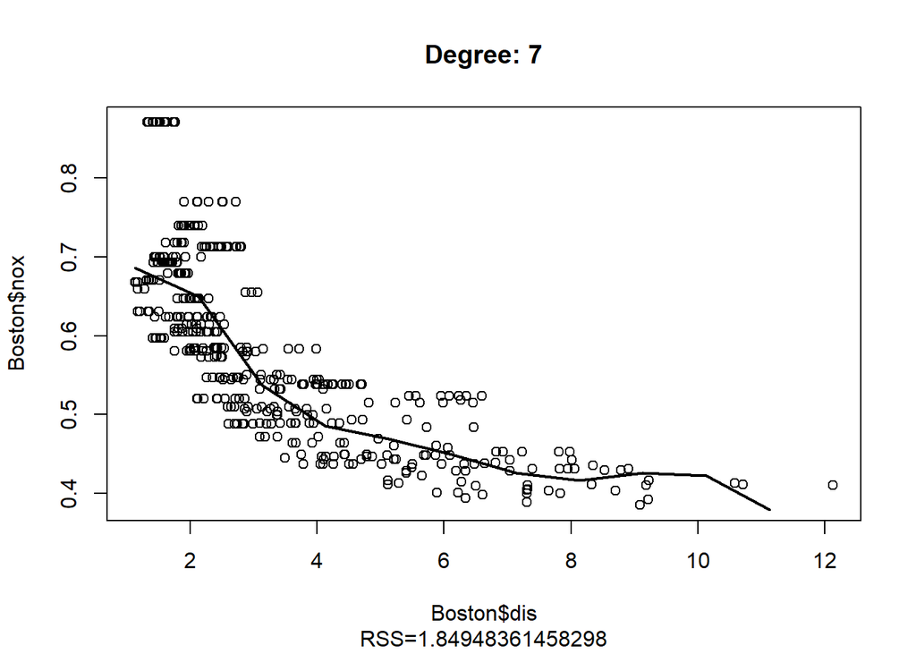

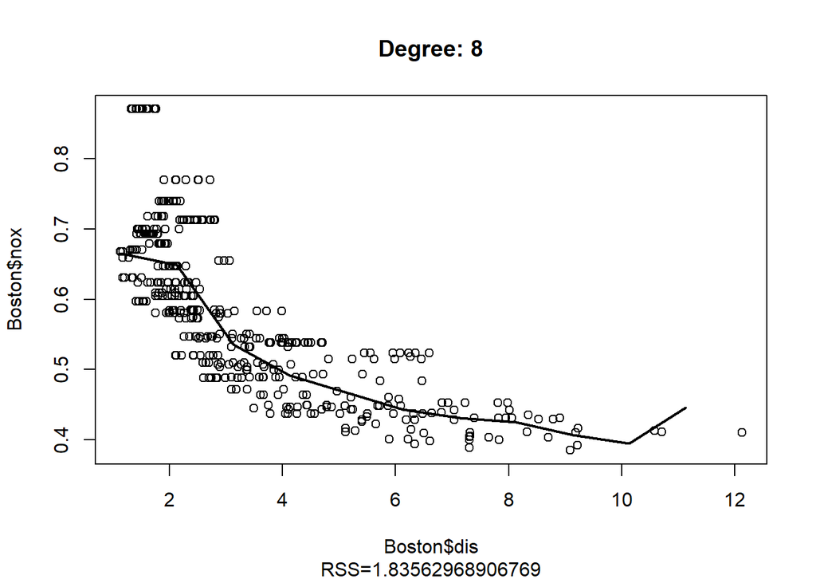

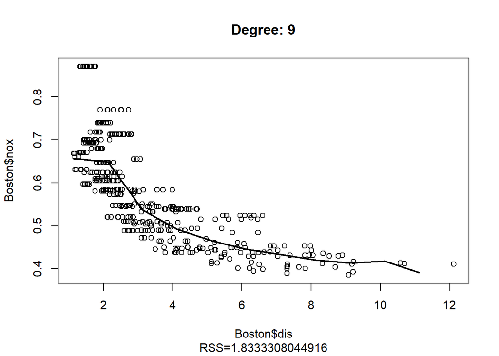

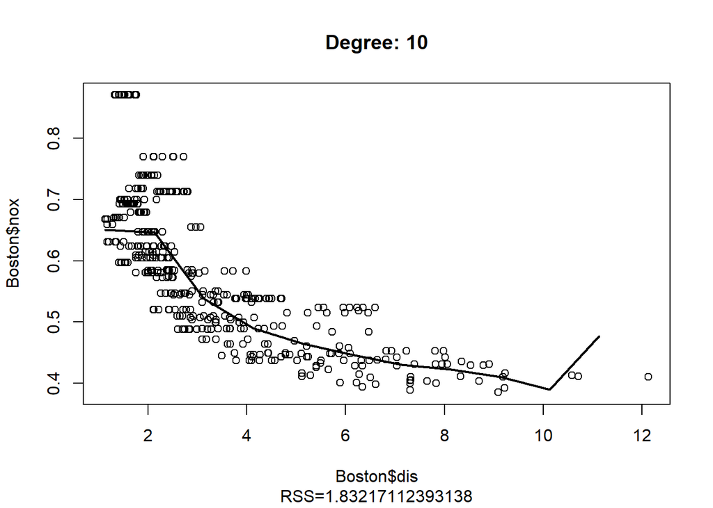

```r
for(degree in 1:10){
  poly_lm = lm(nox ~ poly(dis, degree), data=Boston)
  poly_lm_pred = predict(poly_lm, newdata=list(dis = dis_grid), se=TRUE)
  plot(Boston$dis, Boston$nox, xlim=dis_range)
  title(paste0("Degree: ", degree))
  lines(dis_grid, poly_lm_pred$fit, lwd=2)
  title(sub=paste0("RSS=", sum(poly_lm$residuals^2)))
}
```

#### (c)

```r
set.seed(0)
cv.error = rep(0, 10)

for (degree in 1:10){
  poly_lm = glm(nox ~ poly(dis, degree), data=Boston)
  cv.error[degree] = cv.glm(Boston, poly_lm, K=10)$delta[1]
}
cv.error
```

```
##  [1] 0.005530653 0.004075342 0.003853017 0.003895516 0.004227732
##  [6] 0.005203832 0.014311208 0.016315803 0.021706354 0.007715878
```

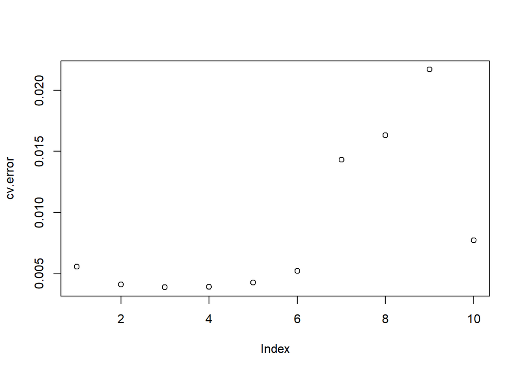

```r
plot(cv.error)
```

There are not much difference in degrees 2-5 models, these model all performance well. The cross-validation errors of degrees 1 and 6 model are little higher than degrees 2-5 models, but the cross-validation errors are still acceptable. The degrees 7-10 models has higher cross-validation errors. Degrees 10 model has less cross-validation error than degrees 7-9 models,but has higher cross-validation error than degrees 1-6 models.Degrees 3 has the lowest cross-validation error, which is 0.003853017.

#### (d)

```r
library(splines)
```

```r
splines_lm = lm(nox ~ bs(dis, df=4), data=Boston)
summary(splines_lm)
```

```
##
## Call:
## lm(formula = nox ~ bs(dis, df = 4), data = Boston)
##
## Residuals:
##       Min        1Q    Median        3Q       Max
## -0.124622 -0.039259 -0.008514  0.020850  0.193891
##
## Coefficients:
##                  Estimate Std. Error t value Pr(>|t|)
## (Intercept)       0.73447    0.01460  50.306  < 2e-16 ***
## bs(dis, df = 4)1 -0.05810    0.02186  -2.658  0.00812 **
## bs(dis, df = 4)2 -0.46356    0.02366 -19.596  < 2e-16 ***
## bs(dis, df = 4)3 -0.19979    0.04311  -4.634 4.58e-06 ***
## bs(dis, df = 4)4 -0.38881    0.04551  -8.544  < 2e-16 ***
## ---
## Signif. codes:  0 '***' 0.001 '**' 0.01 '*' 0.05 '.' 0.1 ' ' 1
##
## Residual standard error: 0.06195 on 501 degrees of freedom
## Multiple R-squared:  0.7164, Adjusted R-squared:  0.7142
## F-statistic: 316.5 on 4 and 501 DF,  p-value: < 2.2e-16
```

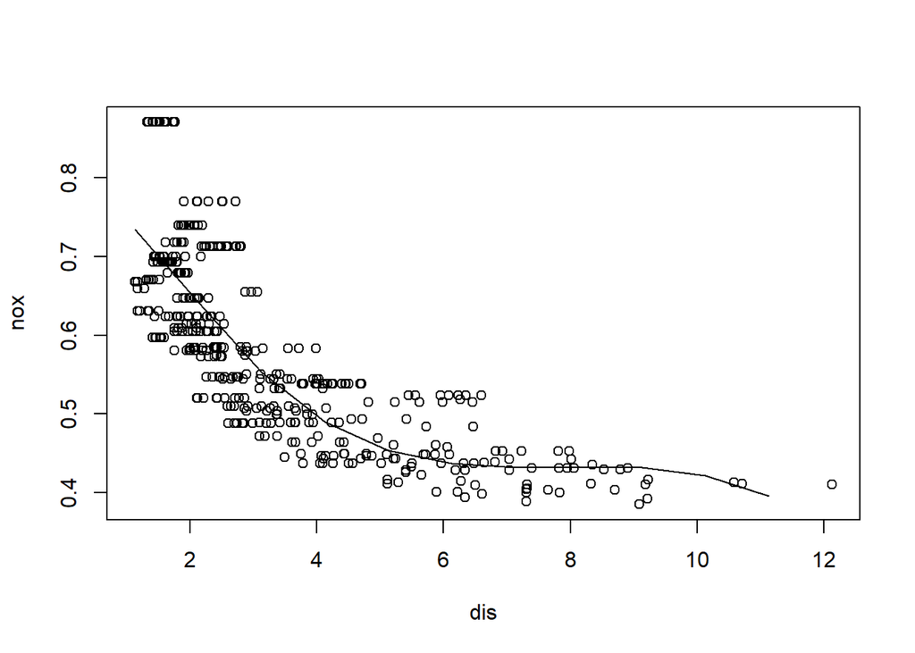

```r
splines_pred = predict(splines_lm, list(dis = dis_grid))
plot(nox ~ dis, data = Boston)
lines(dis_grid, splines_pred)
```

Plot shows that the spline fits data well.

#### (e)

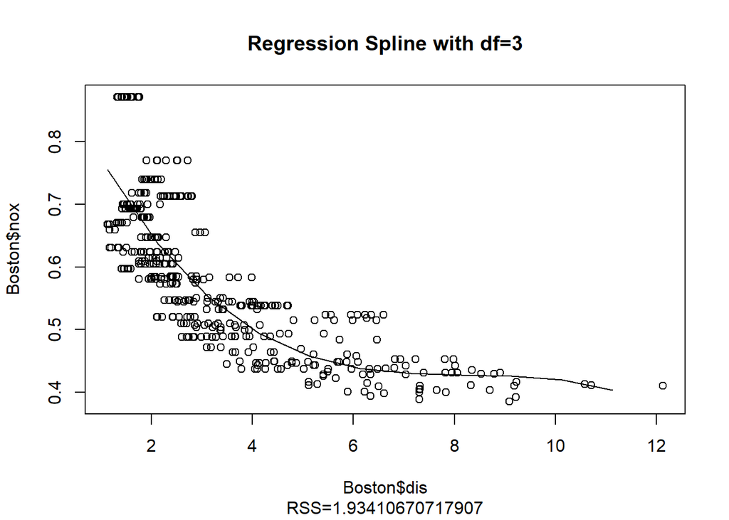

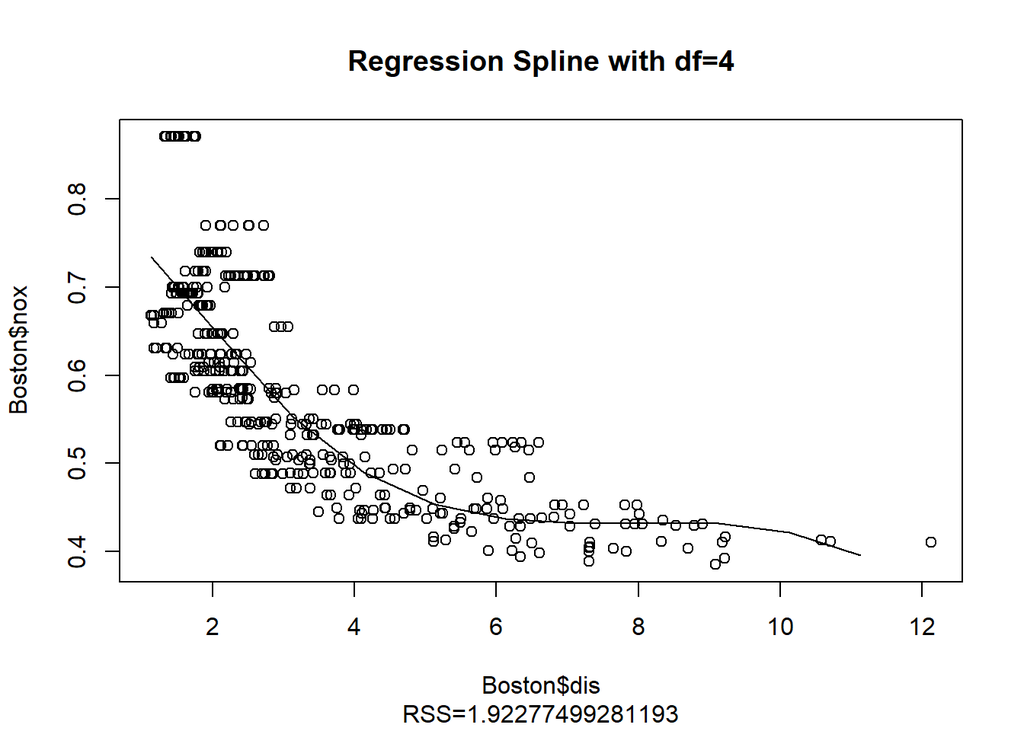

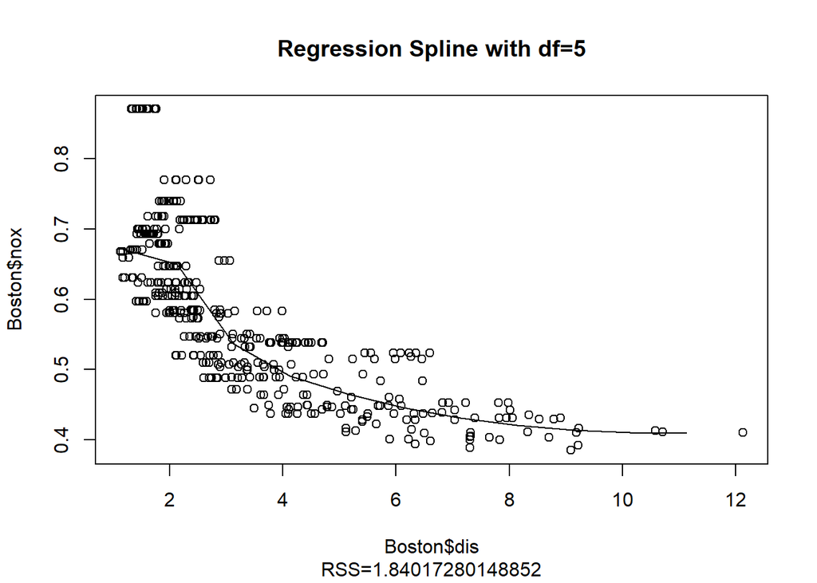

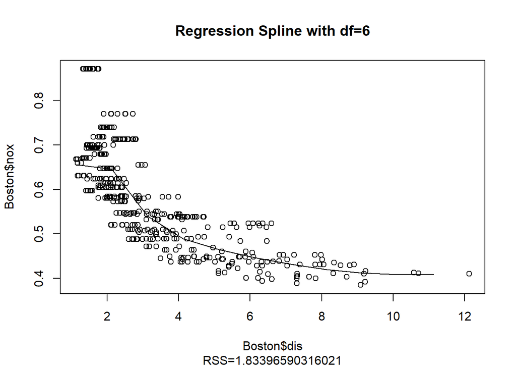

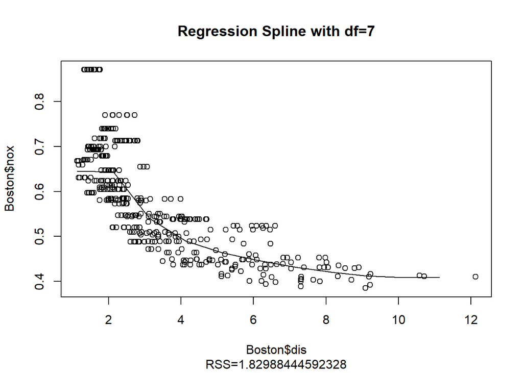

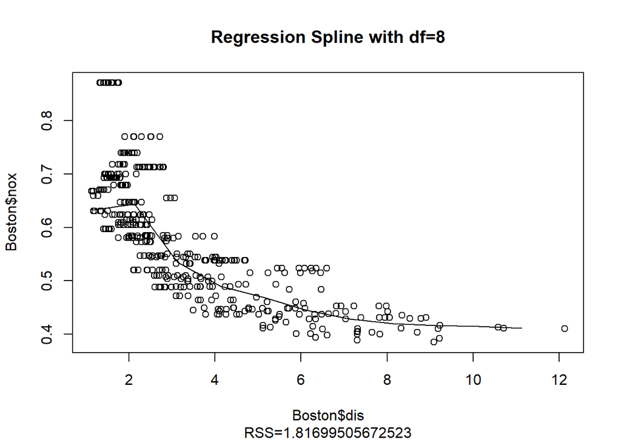

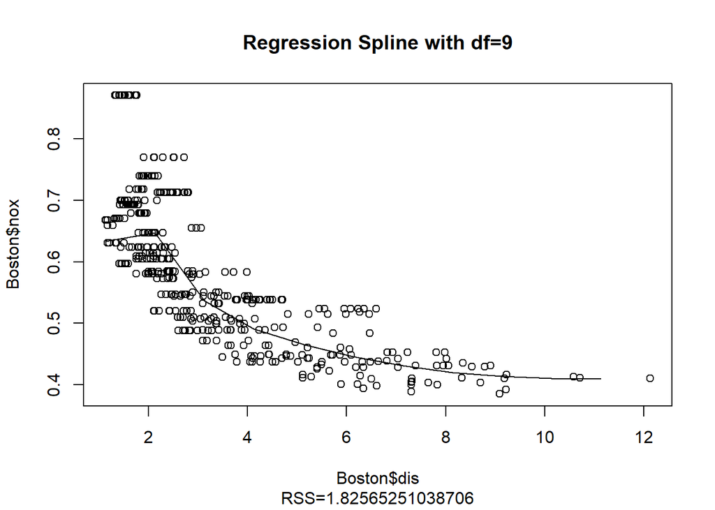

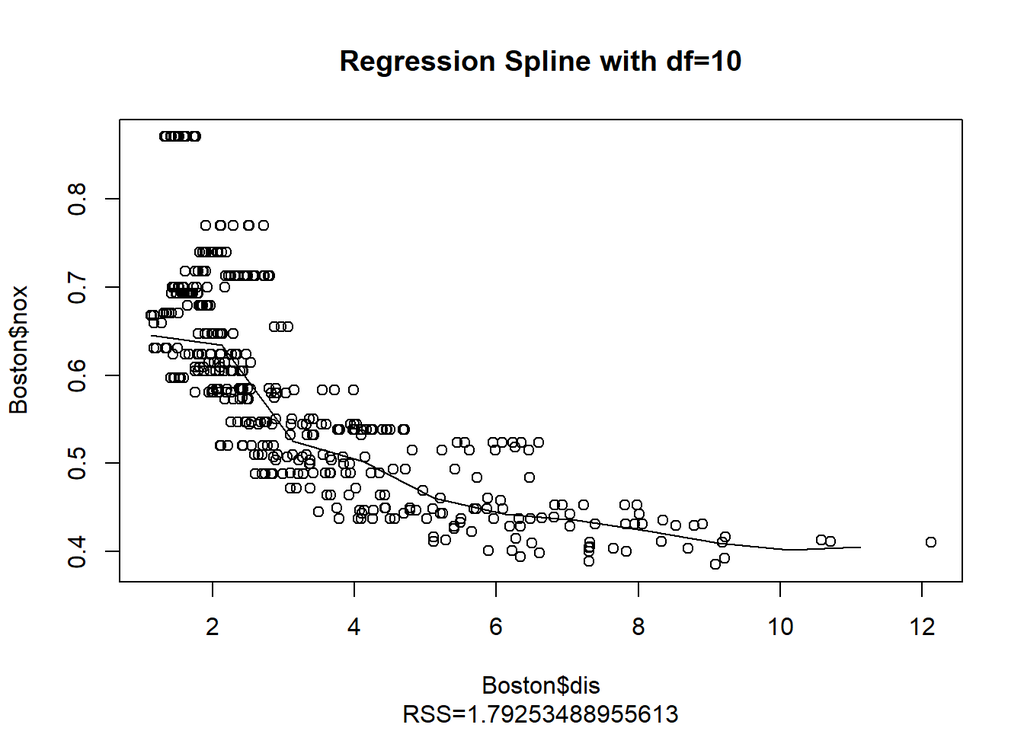

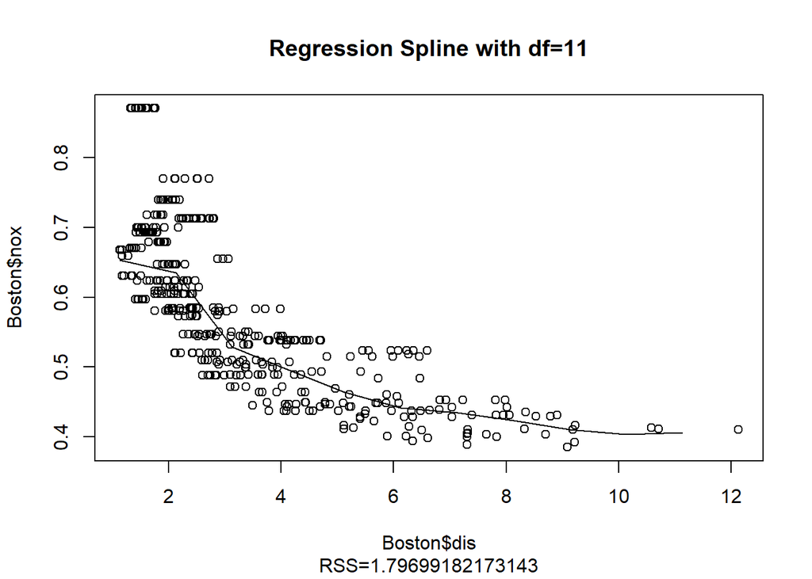

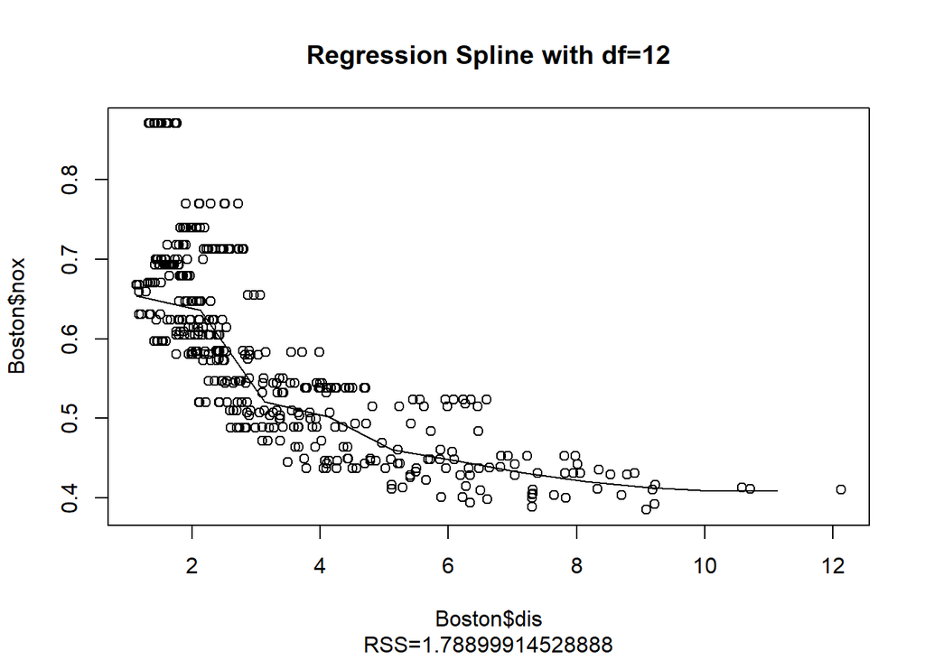

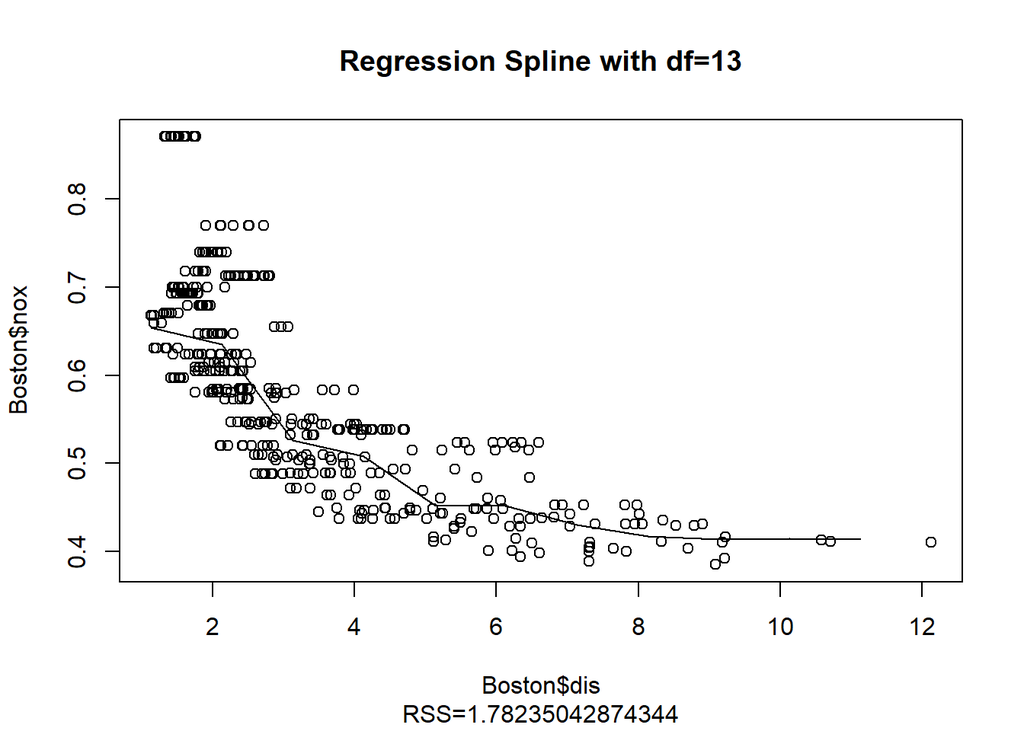

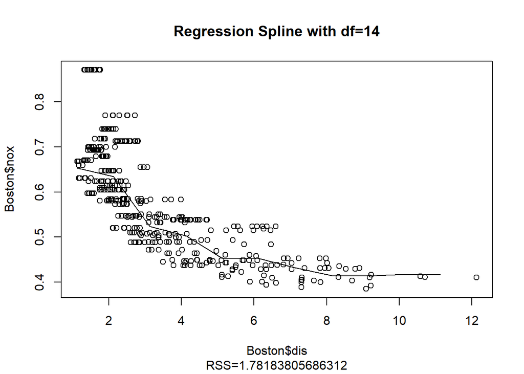

[3 more figures not shown]

```r
rss = rep(0,15)

for(df in 3:17){
  splines_lm = lm(nox ~ bs(dis, df=df), data=Boston)
  splines_preds = predict(splines_lm, newdata=list(dis = dis_grid),se=TRUE)
  plot(Boston$dis, Boston$nox, xlim=dis_range)
  title(paste0("Regression Spline with df=", df))
  lines(dis_grid, splines_preds$fit)
  title(sub=paste0("RSS=", sum(splines_lm$residuals^2)))
  rss[df-2] = sum(splines_lm$residuals^2)
}
```

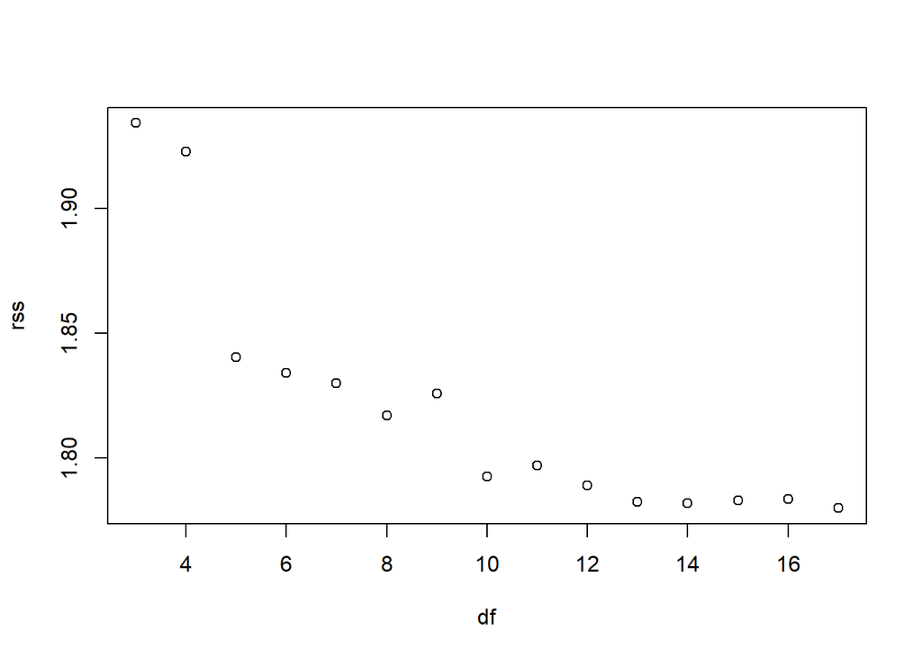

```r
df = seq(3,17)
plot(df, rss)
```

According to these results, we can find that when df is bigger than 13, the rss becomes stable. The rss increase little firstly and then decrease little.

#### (f)

```r
set.seed(0)
cv.error = rep(0, 15)

for (df in 3:17){
  splines_lm = glm(nox ~ bs(dis, df=df), data=Boston)
  cv.error[df-2] = cv.glm(Boston, splines_lm, K=10)$delta[1]

}
```

```r
cv.error
```

```
##  [1] 0.003865091 0.003871597 0.003678119 0.003688405 0.003736403
##  [6] 0.003689184 0.003763004 0.003647312 0.003703312 0.003714537
## [11] 0.003690434 0.003750928 0.003745098 0.003754465 0.003717022
```

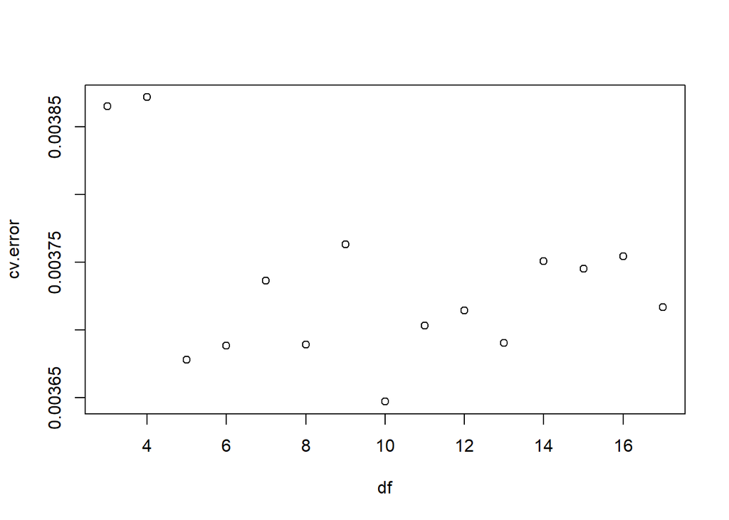

```r
df = seq(3,17,1)
plot(df, cv.error)
```

The overall trend of cross-validation error is that cross-validation error increases with df increases, except for df = 3 and df = 4 two models. When df = 10, the model has lowest cross-validation error.So I choose that one as the best.